# Duolingo SLAM data

[Matthew Walsh]

# Introduction

Duolingo is a free online language-learning platform. Since launching in 2012, hundres of millions of learners worldwide have enrolled in Duolingo’s courses either via the website or mobile apps.

Online platforms like Duolingo have recently been used to create massive datasets drawn from diverse learners who complete activities in a self-paced manner, on personal devices, and at their preferred times and locations. These data create a unique opportunity to go beyond the laboratory, and to study human learning and memory in more naturalistic conditions.

In this notebook, I analyze a large sample of data gathered from Duolingo to determine factors that contribute to the acquisition and retention of foreign language vocabulary.

### Psychology of Learning and Memory

Learning refers to the acquisition of knowledge, skills, and abilities (KSAs) needed to enable long-lasting behavioral change, and memory refers to the mental records of knowledge and experiences that underlie that change.

For more than a century, psychologists have conducted experiments to identify factors that impact the acquisition and retention of knowledge. These studies have revealed that the acquisition and retention of knowledge is impacted by at least three primary factors.

1. Amount of practice. Performance improves with the number of previous practice repetitions.
2. Elapsed time since practice. Performance decreases with the elapsed time since practice occured.
3. Temporal distribution of practice. Increasing the amount of time, or ‘spacing’ between practice repetitions increases retention.

### Duolingo SLAM

The Second Language Acquisition Modeling (SLAM) dataset contains over 2 million words and answers from over 6,000 students during their first 30 days of using Duolingo in 2018. Students were from three language tracks: native French speakers learning English, native Spanish speakers learning English, and native English speakers learning Spanish. Students answered three types of questions: translate required translating a word from one’s native language (L1) to the second language (L2); select required selecting the correct translation from a word bank; and listen required translating a spoken word from L2 to L1. All questions involved a single vocabulary item. SLAM contains student- and item-level information on study history and performance (i.e., response accuracy), as well as metadata descriptors including question format, language, and part of speech.

# Results

I used the Duolingo SLAM dataset to examine the effects of practice and recency on performance.

### Effects of Repetitions on Performance

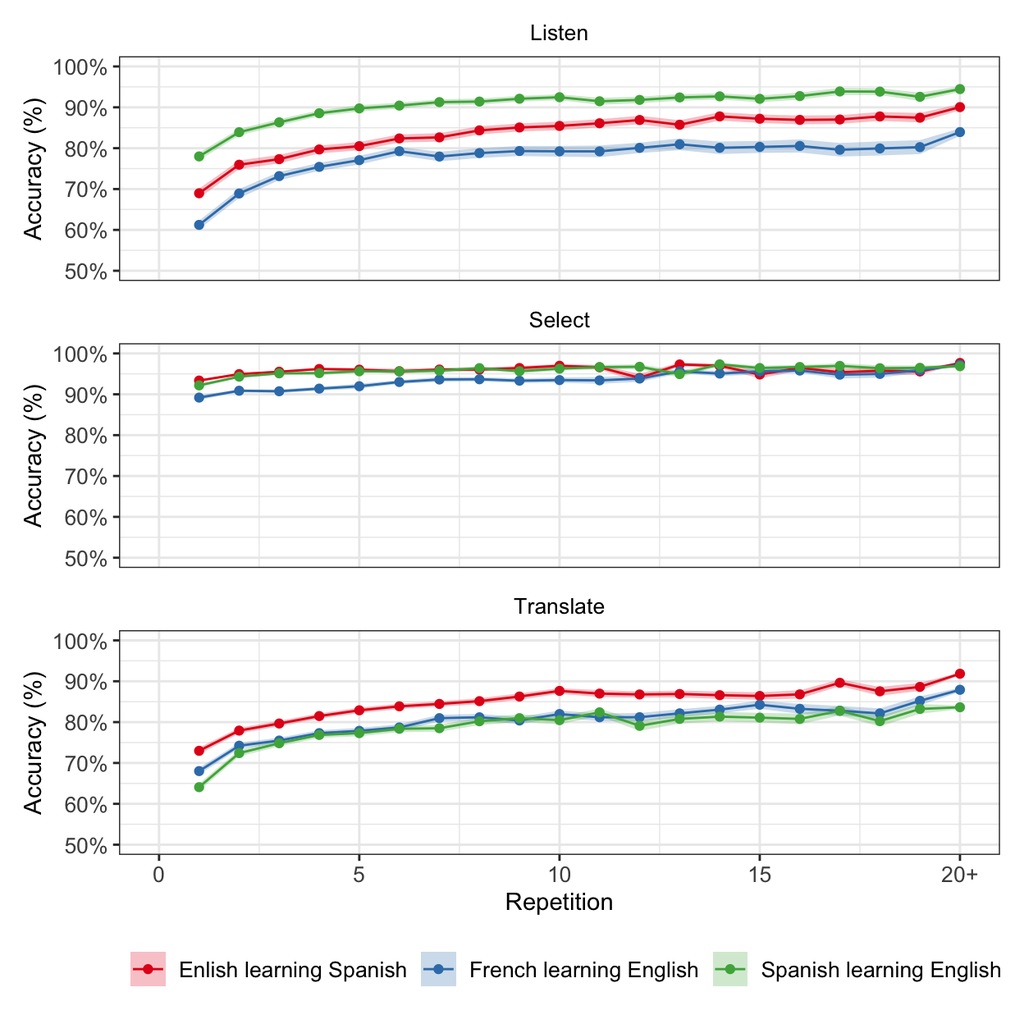

Figure 1. Performance based on language, prompt type, and number of repetitions

### Effects of Lag on Performance

Another fundamental finding from learning science research is that performance decreases with elapsed time since practice occurred. In SLAM, the elapsed time since previous exposure to a word is a continuously varying value. To visualize the data, we combined elapsed times into bins ranging from minutes, to hours, to days, as displayed in Figure 2. The lines show how the average user’s response accuracy changed based on the elapsed time since they had last studied the word. Accuracy decreased with the length of the retention interval and varied by question type and language.

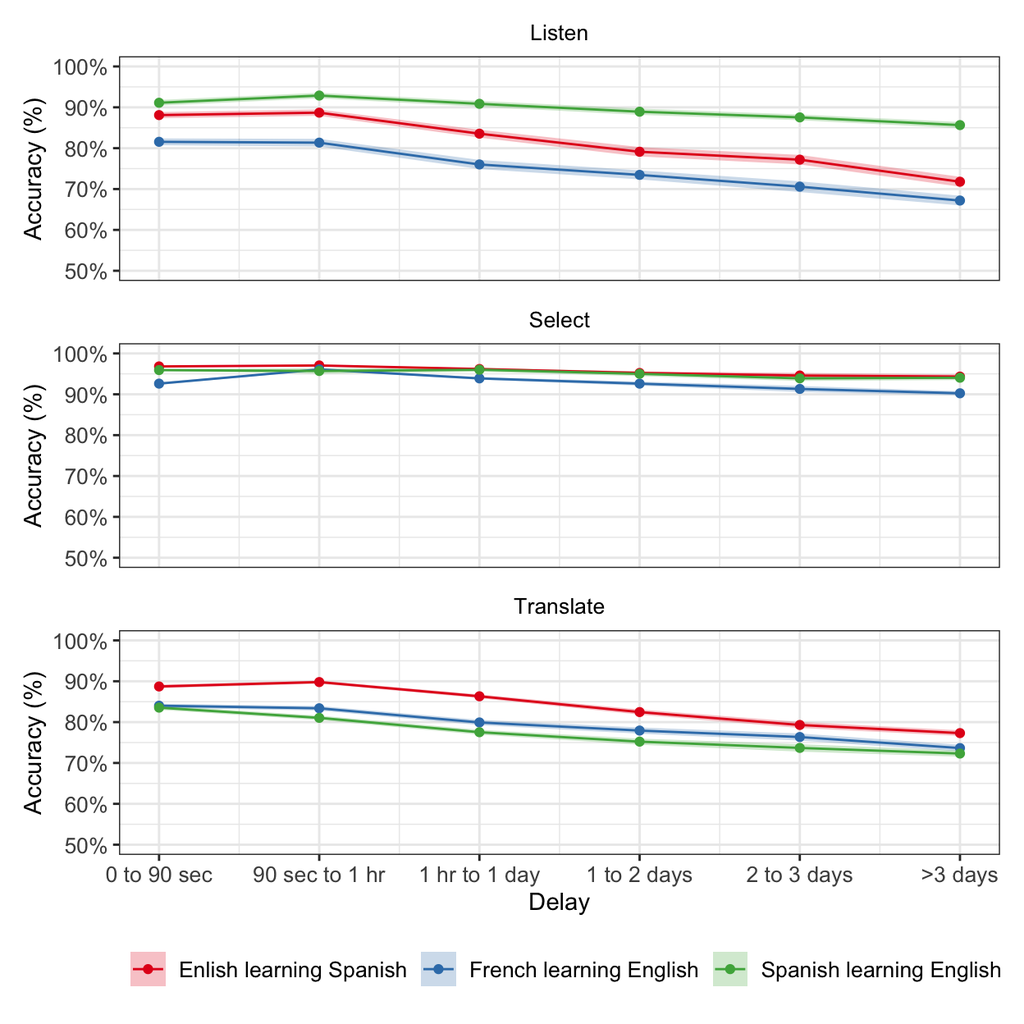

Figure 2. Performance based on language, prompt type, and time since last repetition

### Statistical Analysis of Effects

To confirm the observations from Figures 1 and 2, we performed a logistic regression treating item-level response accuracy as the outcome, and treating question type, language, number of practice repetitions, and elapsed time since the previous repetition as predictors. Table 1 shows the odds ratios and 95 percent confidence intervals estimated for the effects. Values less than 1.0 indicate that the factor reduces the probability of a correct response, and values greater than 1.0 indicate that the factor increases the probability of a correct response.

Accuracy was lowest the first time a word was tested, increased with the number of repetitions, and decreased with the elapsed time since the previous repetition. In addition, accuracy varied by question type and language. This analysis confirms how response accuracy is affected by amount of practice and elapsed time since practice occurred. It also demonstrates that secondary factors like language and question type can further affect performance.

| Term | Estimate | Lower.Bound | Upper.Bound |
| --- | --- | --- | --- |
| (Intercept) | 5.51 | 5.41 | 5.62 |
| first | 0.59 | 0.58 | 0.60 |
| history_seen_log | 1.28 | 1.27 | 1.28 |
| languageFrench learning English | 0.73 | 0.72 | 0.74 |
| languageSpanish learning English | 1.02 | 1.01 | 1.03 |
| formatSelect | 3.21 | 3.17 | 3.26 |
| formatTranslate | 0.87 | 0.87 | 0.88 |
| lag_log:fit_lag | 0.95 | 0.95 | 0.95 |